# Final Exam

Question 1

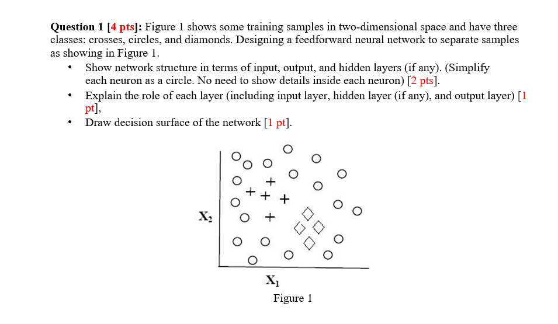

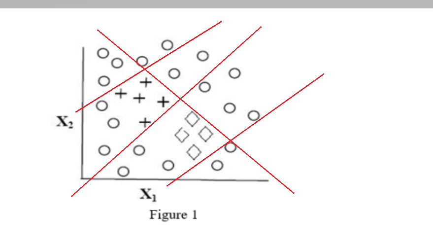

Input weights w1, w2, w3

Output neuron Oi

Working The basic unit of computation in a neural network is the neuron, often called a node or unit. It receives input from some other nodes, or from an external source and computes an output. Each input has an associated weight (w), which is assigned on the basis of its relative importance to other inputs.

1. Input Nodes – The Input nodes provide information from the outside world to the network and are together referred to as the “Input Layer”. No computation is performed in any of the Input nodes – they just pass on the information to the hidden nodes.
2. Hidden Nodes – The Hidden nodes have no direct connection with the outside world (hence the name “hidden”). They perform computations and transfer information from the input nodes to the output nodes. A collection of hidden nodes forms a “Hidden Layer”. While a feedforward network will only have a single input layer and a single output layer, it can have zero or multiple Hidden Layers.
3. Output Nodes – The Output nodes are collectively referred to as the “Output Layer” and are responsible for computations and transferring information from the network to the outside world.
4. Bias Nodes - The bias node in a neural network is a node that is always 'on'. That is, its value is set to 1 without regard for the data in a given pattern. It is analogous to the intercept in a regression model, and serves the same function.

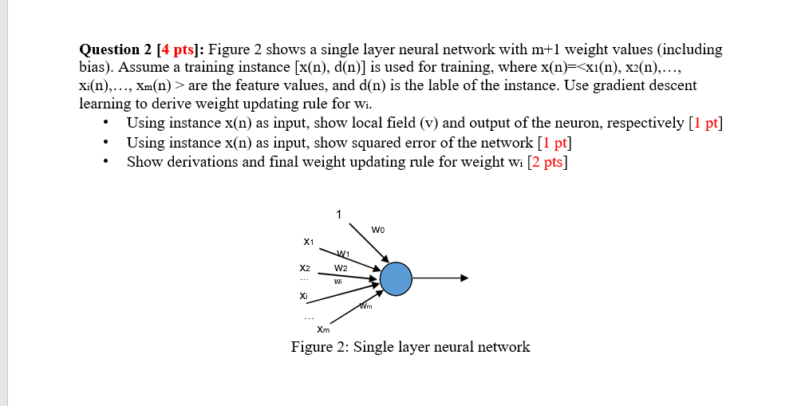

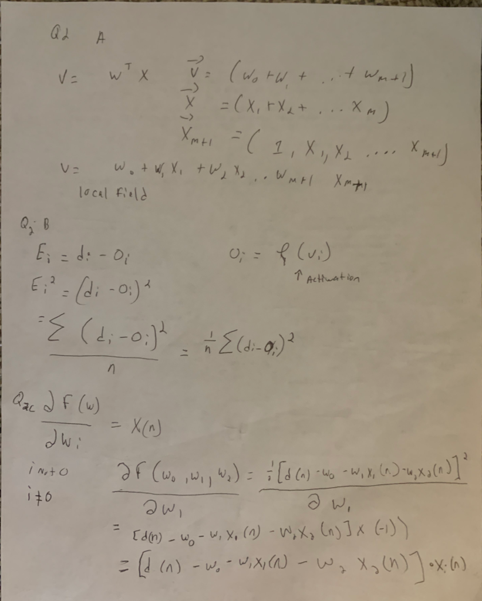

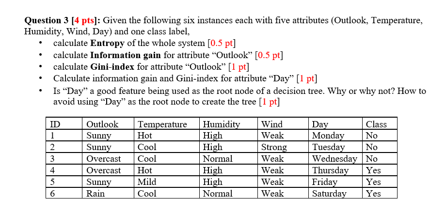

```python
import pandas as pd
from math import log2
import numpy as np
import matplotlib.pyplot as plt
from numpy.linalg import norm
```

```python
def calculate_entropy(data_frame, column):
    sum = 0
    current_unique = data_frame[column].unique()
    for i in current_unique:
        req1 = data_frame[column].value_counts()[i]/len(data_frame)
        req2 = log2(data_frame[column].value_counts()[i]/len(data_frame))
        sum+= -(req1)*req2
    return sum

def calculate_cond_entropy(current_column,data_frame,select_col):
    summed = 0
    collected_entropies = {}
    unique_vals = data_frame[current_column].unique()
    for i in unique_vals:
            val1 = (data_frame[current_column].value_counts()[i]/len(data_frame))
            val2 = calculate_entropy(data_frame[data_frame[current_column]==i], select_col)
            summed+= val1 * val2
            val3 = [calculate_entropy(data_frame[data_frame[current_column]==i], select_col)]
            collected_entropies[i] = val3
    return [summed, collected_entropies]

def calculate_information_gain(data_frame, current_column, select_col):
    req1 = calculate_entropy(data_frame, select_col)
    req2 = calculate_cond_entropy(current_column,data_frame,select_col)[0]
    req3 = calculate_cond_entropy(current_column,data_frame,select_col)[0]
    req4 = calculate_cond_entropy(current_column,data_frame,select_col)[1]
    return req1 - req2, req3,req4

def gini_calc(data_frame, col):
    sum =0
    unique_values = data_frame[col].unique()
    for i in unique_values:
        req1 = (data_frame[col].value_counts()[i]/len(data_frame))
        sum+= req1**2
    return 1 - sum

def gini_calc_(df, col, current_col):
    sum = 0
    unique_values = df[col].unique()
    for i in unique_values:
        req1 =  (df[col].value_counts()[i]/len(df))
        req2 = gini_calc(df[df[col]==i], current_col)
        sum+=req1*req2
    return sum
```

```python
imported_values = pd.read_excel("hw.xlsx")
imported_values
```

|  | Outlook | Temperature | Humidity | Wind | Day | Class |
| --- | --- | --- | --- | --- | --- | --- |
| 0 | Sunny | Hot | High | Weak | Monday | No |
| 1 | Sunny | Cool | High | Strong | Tuesday | No |
| 2 | Overcast | Cool | Normal | Weak | Wednesday | No |
| 3 | Overcast | Hot | High | Weak | Thursday | Yes |
| 4 | Sunny | Mild | High | Weak | Friday | Yes |
| 5 | Rain | Cool | Normal | Weak | Saturday | Yes |

```python
calculate_entropy(imported_values, "Class")
```

```
1.0
```

```python
calculate_information_gain(imported_values, "Outlook", "Class")
```

```
(0.20751874963942196,
 0.792481250360578,
 {'Sunny': [0.9182958340544896], 'Overcast': [1.0], 'Rain': [0.0]})
```

```python
print(gini_calc_(hw, "Outlook", "Class"))
print(gini_split(hw, "Day", "Class"))
```

```
0.38888888888888884
0.0
```

```python
calculate_information_gain(hw, "Day", "Class")
```

```
(1.0,
 0.0,
 {'Monday': [0.0],
  'Tuesday': [0.0],
  'Wednesday': [0.0],
  'Thursday': [0.0],
  'Friday': [0.0],
  'Saturday': [0.0]})
```

Output class of the decision tree is the parent class. The entropy of the system is nothing but the entropy of parent. In this case, the parent is a class variable. Class Variable No 3 data points Yes 3 data points

1) The entropy of the system is 1

2) H(Y)=E(S)=1(Calculated in question 1)

If (Outlook=sunny & Class= YES), probability = 1/3

If (Outlook=sunny & Class= NO), probability = 2/3

H(Y==Sunny)=-1/3*log(1/3) - -2/3* log(2/3)=0.91

If (Outlook=OVERCAST & Class= YES), probability = 1/2

If (Outlook=OVERCAST & Class= NO), probability = 1/2

H(Y==Overcast)=-1/2*log(1/2) - -1/2* log(1/2)=1

If (Outlook=RAINY & Class= YES), probability = 1

If (Outlook=RAINY & Class= NO), probability = 0

H(Y==Rainy)=-1/1*log(1/1) - -0/1* log(0/1)=0

Infogain(Outlook)=1-((3/6)*0.91+(2/6)*1+(1/6)*0) =1-(0.5*0.91+0.33) = 0.215

3) P(Outlook=sunny): 3/6

P(Outlook=Overcast): 2/6

P(Outlook=Rainy): 1/6

If (Outlook=sunny & Class= YES), probability = 1/3

If (Outlook=sunny & Class= NO), probability = 2/3

Gini index = 1 - ((1/3)2 + (2/3)2) = 0.44

If (Outlook=OVERCAST & Class= YES), probability = 1/2

If (Outlook=OVERCAST & Class= NO), probability = 1/2

Gini index = 1 - ((1/2) + 2(1/2)2) = 0.5 If (Outlook=RAINY & Class= YES), probability = 1

If (Outlook=RAINY & Class= NO), probability = 0

Gini index = 1 - ((1)2 + (0)2) = 0

The weighted sum of the Gini Indices can be calculated as follows: Gini Index for Outlook = (3/6)*0.44 + (2/6)*0.5+(1/6)*0 = 0.385

Question 4

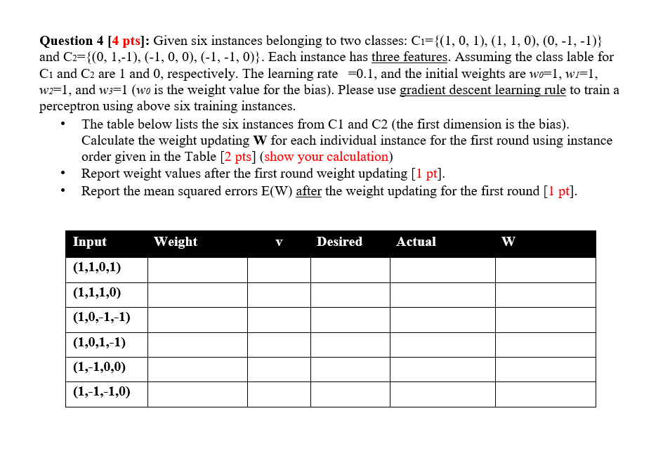

```python
def gradientDescent_question4(num_iter, learning_rate, w):
    df = pd.DataFrame({"X1":[1, 1, 0, 0, -1, -1],
                   "X2":[0, 1, -1, 1, 0, -1],
                   "X3":[1, 0, -1, -1, 0, 0],
                    "y":[1, 1, 1, 0, 0, 0]})
    passed_in_features = df[["X1", "X2", "X3"]].values
    labels = df.y.values
    columns =  ["round", "Input", 'Weight', 'v', 'Desired', 'lr(d(n)-o(n))', 'Delta Wi', 'Delta W', "E", "W(k+1)"]
    results = pd.DataFrame(columns = columns)
    j=1
    for round in range(num_iter):
        w_=w
        accuracy_delta = np.zeros(len(w))
        errors = []
        for i, x in enumerate(passed_in_features):
            x = np.insert(x,0,1)
            v=np.dot(w, x.transpose())
            output = learning_rate*(labels[i]-v)
            errors.append( labels[i]-v)
            deltaw = output*x
            accuracy_delta += deltaw
            cols = ["round", "Input", 'Weight', 'v', 'Desired', 'lr(d(n)-o(n))', 'Delta Wi', 'Delta W']
            results.loc[j,cols] = [round+1, x, ["%2.2f"%k for k in w_],
                                   v, labels[i],
                                   output, ["%2.2f"%k for k in deltaw],
                                   np.array(["%2.2f"%k for k in accuracy_delta])]
            j+=1
        w = w + accuracy_delta
        equation = (np.array(errors)**2.0).sum()/len(passed_in_features)
        results.loc[j-1, ["E", "W(k+1)"]] = [equation, ["%2.1f"%k for k in w]]
    return results


gradientDescent_question4(num_iter=1, learning_rate=0.1,   w = np.array([1, 1, 1, 1]))
```

|  | round | Input | Weight | v | Desired | lr(d(n)-o(n)) | Delta Wi | Delta W | E | W(k+1) |
| --- | --- | --- | --- | --- | --- | --- | --- | --- | --- | --- |
| 1 | 1 | [1, 1, 0, 1] | [1.00, 1.00, 1.00, 1.00] | 3 | 1 | -0.2 | [-0.20, -0.20, -0.00, -0.20] | [-0.20, -0.20, 0.00, -0.20] | NaN | NaN |
| 2 | 1 | [1, 1, 1, 0] | [1.00, 1.00, 1.00, 1.00] | 3 | 1 | -0.2 | [-0.20, -0.20, -0.20, -0.00] | [-0.40, -0.40, -0.20, -0.20] | NaN | NaN |
| 3 | 1 | [1, 0, -1, -1] | [1.00, 1.00, 1.00, 1.00] | -1 | 1 | 0.2 | [0.20, 0.00, -0.20, -0.20] | [-0.20, -0.40, -0.40, -0.40] | NaN | NaN |
| 4 | 1 | [1, 0, 1, -1] | [1.00, 1.00, 1.00, 1.00] | 1 | 0 | -0.1 | [-0.10, -0.00, -0.10, 0.10] | [-0.30, -0.40, -0.50, -0.30] | NaN | NaN |
| 5 | 1 | [1, -1, 0, 0] | [1.00, 1.00, 1.00, 1.00] | 0 | 0 | 0.0 | [0.00, -0.00, 0.00, 0.00] | [-0.30, -0.40, -0.50, -0.30] | NaN | NaN |
| 6 | 1 | [1, -1, -1, 0] | [1.00, 1.00, 1.00, 1.00] | -1 | 0 | 0.1 | [0.10, -0.10, -0.10, 0.00] | [-0.20, -0.50, -0.60, -0.30] | 2.333333 | [0.8, 0.5, 0.4, 0.7] |

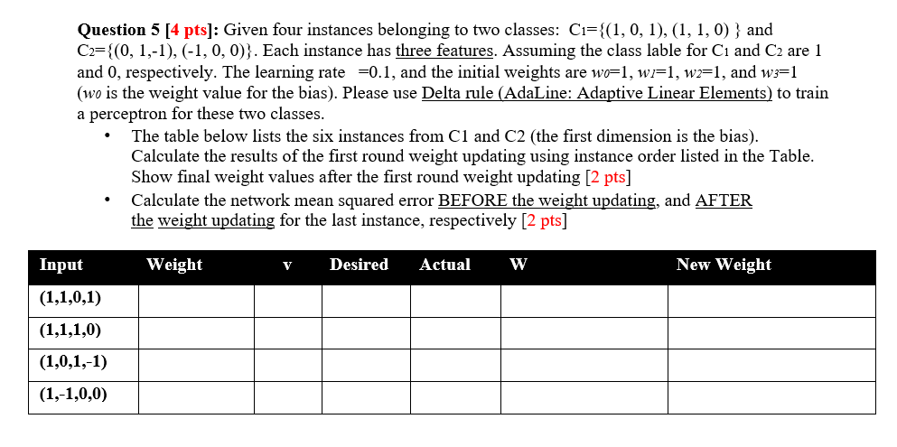

```python
def delta_question_5(labels, num_iter, learning_rate, w):
    df = pd.DataFrame({"X1":[1, 1, 0, -1],
                   "X2":[0, 1, 1, 0],
                   "X3":[1, 0, -1, 0],
                    "y":[1, 1, 0, 0,]})
    features = df[["X1", "X2", "X3"]].values
    cols = ["Round", "Input", 'Weight', 'd', 'O', 'lr(d-O)Xi', 'New Weight', "Error"]
    results = pd.DataFrame(columns = cols)
    j = 0
    error = 0
    for round in range(num_iter):
        for i, x in enumerate(features):
            x = np.insert(x, 0, 1)
            v= np.dot(w, x.transpose()) #==>O
            current_delta = learning_rate * (labels[i]-v) * x #lr*(d-o)x
            error = error + (labels[i]-v)**2
            w_ = w
            w = w + current_delta
            j+=1
            cols = ["Round", "Input", 'Weight', 'd', 'O', 'lr(d-O)Xi', 'New Weight']
            results.loc[j,cols] = [round+1,
                                        x,
                                        np.array(["%2.1f"%k for k in w_ ]),
                                        labels[i],
                                        v,
                                        ["%2.1f"%k for k in current_delta ],
                                        ["%.1f"%k for k in w ]]

            if (j%len(features)==0):
                 results.loc[j,"Error"] = error/len(features)

    return results
delta_question_5(df.y.values, num_iter=1, learning_rate=0.1, w = np.array([1, 1, 1,1]))
```

|  | Round | Input | Weight | d | O | lr(d-O)Xi | New Weight | Error |
| --- | --- | --- | --- | --- | --- | --- | --- | --- |
| 1 | 1 | [1, 1, 0, 1] | [1.0, 1.0, 1.0, 1.0] | 1 | 3 | [-0.2, -0.2, -0.0, -0.2] | [0.8, 0.8, 1.0, 0.8] | NaN |
| 2 | 1 | [1, 1, 1, 0] | [0.8, 0.8, 1.0, 0.8] | 1 | 2.6 | [-0.2, -0.2, -0.2, -0.0] | [0.6, 0.6, 0.8, 0.8] | NaN |
| 3 | 1 | [1, 0, 1, -1] | [0.6, 0.6, 0.8, 0.8] | 0 | 0.68 | [-0.1, -0.0, -0.1, 0.1] | [0.6, 0.6, 0.8, 0.9] | NaN |
| 4 | 1 | [1, -1, 0, 0] | [0.6, 0.6, 0.8, 0.9] | 0 | -0.068 | [0.0, -0.0, 0.0, 0.0] | [0.6, 0.6, 0.8, 0.9] | 1.756756 |

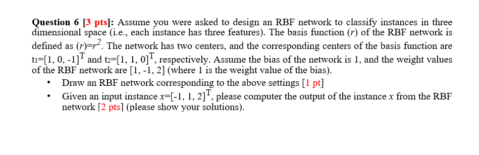

```python
def question6_rbf():
    requirement_inst = pd.DataFrame(
        {"A1":[-1],
          "A2":[1],
         "A3":[2],}
    )
    t1 = np.array([1, 0, -1])
    t2 = np.array([1, 1, 0])
    display(requirement_inst)
    sq = lambda x1, x2,x3, t: norm(np.array([x1, x2, x3]) - t)**2
    data_frame_instance = requirement_inst.iloc[:, :]
    data_frame_instance["z1"] = data_frame_instance.apply(lambda x: sq(x["A1"], x["A2"],x["A3"], t1), axis=1)
    data_frame_instance["z2"] = data_frame_instance.apply(lambda x: sq(x["A1"], x["A2"],x["A3"], t2), axis=1)
    display(data_frame_instance)
    data_frame_instance["Verify"] = data_frame_instance.apply(lambda x: 1 + -1*x["z1"] +2*x["z2"] , axis = 1)
    display(data_frame_instance)
question6_rbf()
```

|  | A1 | A2 | A3 |
| --- | --- | --- | --- |
| 0 | -1 | 1 | 2 |

|  | A1 | A2 | A3 | z1 | z2 |
| --- | --- | --- | --- | --- | --- |
| 0 | -1 | 1 | 2 | 14.0 | 8.0 |

|  | A1 | A2 | A3 | z1 | z2 | Verify |
| --- | --- | --- | --- | --- | --- | --- |
| 0 | -1 | 1 | 2 | 14.0 | 8.0 | 3.0 |

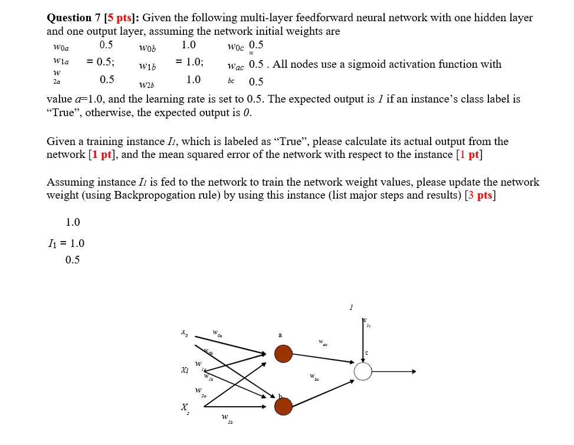

Ob(I1) = $ \Phi $(1.0+1.0+0.5) = 1/(1+e^-1*2.5)=0.9241

now for Oc

what is the mean squared error of the network over the instance given I1

Calculate local gradient of each node

$\delta_c$ = Oc(1 – Oc) * (dc – Oc)

$\delta_b$ = Ob(1 – Ob) *(Wbc* c)

$\delta_a$ = Oa(1 – Oa) *(Wac* c)

Update the network weight using backpropagation rule

$\Delta$ Wc=[$\Delta$WOc, $\Delta$ Wac, $\Delta$ Wbc]=E *$\Delta$ j*Xij=-0.07305

For A $\Delta$ W=E*$\Delta$j*Xij= 0.0025615

Woa 0.5 + 0.0025615 = 0.502515

W1a 0.5 + 0.0025615 = 0.502515

W2a 05 + 0.0025615 = 0.502515